# R Notebook

Step 1: I Load the data and check summary  
We load the dataset from a CSV file and view a summary of its contents to understand the variables and basic statistics.

```r
library(ggplot2)
library(readr)
library(dplyr)
library(lmtest)
library(sandwich)
data <- read_csv("final_df.csv")
```

Step 2: I run basic regression  
I estimate a simple linear regression (reg1) where BMI is explained by whether someone is in NY (NY_dummy), the year (YEAR_dummy), and variables related to fries and health.

```r
summary(data)
```

```
      YEAR         NY_dummy        YEAR_dummy      fryoverload          BMI           STATEFIP       FRIESMO.y
 Min.   :2005   Min.   :0.0000   Min.   :0.0000   Min.   : 0.000   Min.   : 0.00   Min.   : 9.00   Min.   :0.000
 1st Qu.:2006   1st Qu.:0.0000   1st Qu.:0.0000   1st Qu.: 4.868   1st Qu.:22.97   1st Qu.:12.00   1st Qu.:1.000
 Median :2007   Median :0.0000   Median :0.0000   Median : 7.740   Median :26.13   Median :34.00   Median :2.000
 Mean   :2007   Mean   :0.2598   Mean   :0.3881   Mean   :10.805   Mean   :26.51   Mean   :28.38   Mean   :2.646
 3rd Qu.:2009   3rd Qu.:1.0000   3rd Qu.:1.0000   3rd Qu.:13.412   3rd Qu.:30.15   3rd Qu.:36.00   3rd Qu.:4.000
 Max.   :2010   Max.   :1.0000   Max.   :1.0000   Max.   :68.610   Max.   :76.04   Max.   :42.00   Max.   :9.000
     HEALTH         state
 Min.   :1.000   Length:9323
 1st Qu.:1.000   Class :character
 Median :2.000   Mode  :character
 Mean   :2.344
 3rd Qu.:3.000
 Max.   :9.000
```

```r
reg1 <- lm(BMI ~ NY_dummy + YEAR_dummy + FRIESMO.y + fryoverload + HEALTH, data = data)
summary(reg1)
```

```
Call:
lm(formula = BMI ~ NY_dummy + YEAR_dummy + FRIESMO.y + fryoverload +
    HEALTH, data = data)

Residuals:
    Min      1Q  Median      3Q     Max
-28.206  -4.155   0.206   3.653  41.027

Coefficients:
            Estimate Std. Error t value Pr(>|t|)
(Intercept)  9.92552    0.28838  34.418  < 2e-16 ***
NY_dummy     0.28899    0.15089   1.915   0.0555 .
YEAR_dummy   0.10069    0.13761   0.732   0.4644
FRIESMO.y    2.60149    0.05240  49.649  < 2e-16 ***
fryoverload  0.78380    0.01195  65.581  < 2e-16 ***
HEALTH       0.47656    0.05939   8.025 1.14e-15 ***
---
Signif. codes:  0 ‘***’ 0.001 ‘**’ 0.01 ‘*’ 0.05 ‘.’ 0.1 ‘ ’ 1

Residual standard error: 6.389 on 9317 degrees of freedom
Multiple R-squared:  0.3257,    Adjusted R-squared:  0.3253
F-statistic:   900 on 5 and 9317 DF,  p-value: < 2.2e-16
```

Below I perform time series analysis for BMI through the defined timeframe and for all of 6 States in my dataset. This plot helps you visually check whether New York’s BMI trend changed after the policy compared to control states like NJ, CT, MA, PA, and FL.

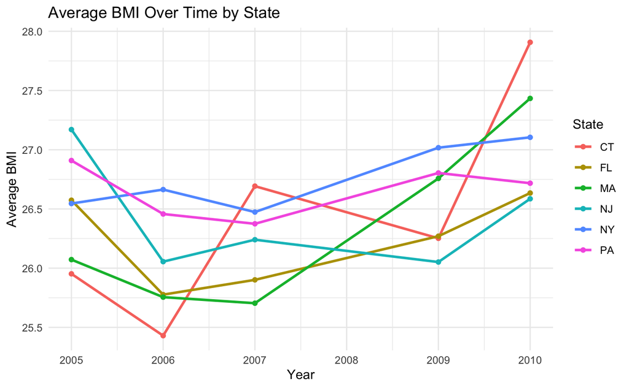

```r
bmi_trends <- data %>%
  group_by(state, YEAR) %>%
  summarize(avg_BMI = mean(BMI, na.rm = TRUE))
ggplot(bmi_trends, aes(x = YEAR, y = avg_BMI, color = state)) +
  geom_line(size = 1) +
  geom_point() +
  labs(title = "Average BMI Over Time by State",
       x = "Year",
       y = "Average BMI",
       color = "State") +
  theme_minimal()
```

Step 3: I run Difference-in-Differences (DiD) regression by adding an interaction term between NY_dummy and YEAR_dummy to check if BMI changes in NY after the policy, compared to other states.

```r
reg2 <- lm(BMI ~ NY_dummy * YEAR_dummy + FRIESMO.y + fryoverload + HEALTH, data = data)
summary(reg2)
```

```
Call:
lm(formula = BMI ~ NY_dummy * YEAR_dummy + FRIESMO.y + fryoverload +
    HEALTH, data = data)

Residuals:
    Min      1Q  Median      3Q     Max
-28.216  -4.158   0.206   3.652  41.031

Coefficients:
                    Estimate Std. Error t value Pr(>|t|)
(Intercept)          9.92208    0.29001  34.213  < 2e-16 ***
NY_dummy             0.30265    0.19359   1.563    0.118
YEAR_dummy           0.10979    0.15960   0.688    0.492
FRIESMO.y            2.60153    0.05240  49.646  < 2e-16 ***
fryoverload          0.78382    0.01195  65.575  < 2e-16 ***
HEALTH               0.47640    0.05941   8.019 1.19e-15 ***
NY_dummy:YEAR_dummy -0.03483    0.30913  -0.113    0.910
---
Signif. codes:  0 ‘***’ 0.001 ‘**’ 0.01 ‘*’ 0.05 ‘.’ 0.1 ‘ ’ 1

Residual standard error: 6.389 on 9316 degrees of freedom
Multiple R-squared:  0.3257,    Adjusted R-squared:  0.3253
F-statistic: 749.9 on 6 and 9316 DF,  p-value: < 2.2e-16
```

Step 4: Calculate robust standard errors  
We use robust standard errors for reg2 to correct for possible heteroskedasticity and get more reliable p-values.

```r
coeftest(reg2, vcov = vcovHC(reg2, type = "HC1"))
```

```
t test of coefficients:

                     Estimate Std. Error t value  Pr(>|t|)
(Intercept)          9.922077   0.328115 30.2396 < 2.2e-16 ***
NY_dummy             0.302649   0.191502  1.5804    0.1141
YEAR_dummy           0.109791   0.161523  0.6797    0.4967
FRIESMO.y            2.601529   0.060574 42.9478 < 2.2e-16 ***
fryoverload          0.783816   0.013823 56.7029 < 2.2e-16 ***
HEALTH               0.476405   0.067251  7.0840 1.502e-12 ***
NY_dummy:YEAR_dummy -0.034828   0.304866 -0.1142    0.9090
---
Signif. codes:  0 ‘***’ 0.001 ‘**’ 0.01 ‘*’ 0.05 ‘.’ 0.1 ‘ ’ 1
```

```r
cat("\nRegression 1 Results:\n")
```

```
Regression 1 Results:
```

```r
print(summary(reg1))
```

```
Call:
lm(formula = BMI ~ NY_dummy + YEAR_dummy + FRIESMO.y + fryoverload +
    HEALTH, data = data)

Residuals:
    Min      1Q  Median      3Q     Max
-28.206  -4.155   0.206   3.653  41.027

Coefficients:
            Estimate Std. Error t value Pr(>|t|)
(Intercept)  9.92552    0.28838  34.418  < 2e-16 ***
NY_dummy     0.28899    0.15089   1.915   0.0555 .
YEAR_dummy   0.10069    0.13761   0.732   0.4644
FRIESMO.y    2.60149    0.05240  49.649  < 2e-16 ***
fryoverload  0.78380    0.01195  65.581  < 2e-16 ***
HEALTH       0.47656    0.05939   8.025 1.14e-15 ***
---
Signif. codes:  0 ‘***’ 0.001 ‘**’ 0.01 ‘*’ 0.05 ‘.’ 0.1 ‘ ’ 1

Residual standard error: 6.389 on 9317 degrees of freedom
Multiple R-squared:  0.3257,    Adjusted R-squared:  0.3253
F-statistic:   900 on 5 and 9317 DF,  p-value: < 2.2e-16
```

```r
cat("\nRegression 2 (DiD) Results:\n")
```

```
Regression 2 (DiD) Results:
```

```r
print(summary(reg2))
```

```
Call:
lm(formula = BMI ~ NY_dummy * YEAR_dummy + FRIESMO.y + fryoverload +
    HEALTH, data = data)

Residuals:
    Min      1Q  Median      3Q     Max
-28.216  -4.158   0.206   3.652  41.031

Coefficients:
                    Estimate Std. Error t value Pr(>|t|)
(Intercept)          9.92208    0.29001  34.213  < 2e-16 ***
NY_dummy             0.30265    0.19359   1.563    0.118
YEAR_dummy           0.10979    0.15960   0.688    0.492
FRIESMO.y            2.60153    0.05240  49.646  < 2e-16 ***
fryoverload          0.78382    0.01195  65.575  < 2e-16 ***
HEALTH               0.47640    0.05941   8.019 1.19e-15 ***
NY_dummy:YEAR_dummy -0.03483    0.30913  -0.113    0.910
---
Signif. codes:  0 ‘***’ 0.001 ‘**’ 0.01 ‘*’ 0.05 ‘.’ 0.1 ‘ ’ 1

Residual standard error: 6.389 on 9316 degrees of freedom
Multiple R-squared:  0.3257,    Adjusted R-squared:  0.3253
F-statistic: 749.9 on 6 and 9316 DF,  p-value: < 2.2e-16
```

```r
cat("\nRegression 2 (DiD + robust SE) Results:\n")
```

```
Regression 2 (DiD + robust SE) Results:
```

```r
print(coeftest(reg2, vcov = vcovHC(reg2, type = "HC1")))
```

```
t test of coefficients:

                     Estimate Std. Error t value  Pr(>|t|)
(Intercept)          9.922077   0.328115 30.2396 < 2.2e-16 ***
NY_dummy             0.302649   0.191502  1.5804    0.1141
YEAR_dummy           0.109791   0.161523  0.6797    0.4967
FRIESMO.y            2.601529   0.060574 42.9478 < 2.2e-16 ***
fryoverload          0.783816   0.013823 56.7029 < 2.2e-16 ***
HEALTH               0.476405   0.067251  7.0840 1.502e-12 ***
NY_dummy:YEAR_dummy -0.034828   0.304866 -0.1142    0.9090
---
Signif. codes:  0 ‘***’ 0.001 ‘**’ 0.01 ‘*’ 0.05 ‘.’ 0.1 ‘ ’ 1
```

```r
cat("\nYEAR_dummy distribution:\n")
```

```
YEAR_dummy distribution:
```

```r
print(table(data$YEAR_dummy))
```

```
   0    1
5705 3618
```

Step 5: I add squared term for fryoverload  
We create a new variable fryoverload_sq (fryoverload squared) to capture possible nonlinear effects of fry consumption.

```r
data <- data %>%
  mutate(fryoverload_sq = fryoverload^2)
```

Step 7: I run an extended regression with quadratic term  
Basically, I estimate a new model (reg4) including fryoverload_sq, to test if the effect of fryoverload on BMI levels off or changes at higher levels.

```r
reg4 <- lm(BMI ~ NY_dummy * YEAR_dummy + FRIESMO.y + fryoverload + fryoverload_sq + HEALTH, data = data)
summary(reg4)
```

```
Call:
lm(formula = BMI ~ NY_dummy * YEAR_dummy + FRIESMO.y + fryoverload +
    fryoverload_sq + HEALTH, data = data)

Residuals:
    Min      1Q  Median      3Q     Max
-23.483  -2.971   0.468   2.960  84.191

Coefficients:
                     Estimate Std. Error t value Pr(>|t|)
(Intercept)         -3.455311   0.345071 -10.013   <2e-16 ***
NY_dummy             0.200926   0.167193   1.202    0.229
YEAR_dummy           0.120242   0.137831   0.872    0.383
FRIESMO.y            4.043651   0.051988  77.780   <2e-16 ***
fryoverload          2.316963   0.029097  79.628   <2e-16 ***
fryoverload_sq      -0.036915   0.000655 -56.356   <2e-16 ***
HEALTH               0.495179   0.051305   9.652   <2e-16 ***
NY_dummy:YEAR_dummy -0.004363   0.266967  -0.016    0.987
---
Signif. codes:  0 ‘***’ 0.001 ‘**’ 0.01 ‘*’ 0.05 ‘.’ 0.1 ‘ ’ 1

Residual standard error: 5.517 on 9315 degrees of freedom
Multiple R-squared:  0.4971,    Adjusted R-squared:  0.4968
F-statistic:  1316 on 7 and 9315 DF,  p-value: < 2.2e-16
```

CONCLUSIONS/ RESULTS:

R1) In reg2 the interaction has a -0.03 reduction in the BMI of the average NYorker.p-value is very high. The calorie labeling policy in New York does not show a statistically significant effect on BMI in this sample. The near-zero estimate and high p-value suggest no meaningful change in BMI in NY after the policy, relative to control states.

R2) Eating fries frequently is strongly and positively associated with BMI. For every unit increase in fryoverload, BMI increases by roughly 0.78–2.3 units, depending on whether we account for nonlinear effects.

Estimate ≈ 0.78 to 2.31 (depending on the model) p-value ≈ < 0.001 (highly significant)

R3) In the quadratic model (reg4), fryoverload_sq has: Estimate ≈ -0.037 p-value ≈ < 0.001 (highly significant)

The negative coefficient suggests diminishing returns: as fryoverload increases, the additional effect on BMI becomes smaller. In simple terms, the BMI rise slows down at very high levels of fry consumption.

THE END